# Vegan package exploration

Caroline

2022-11-09

## (1) Package description

The vegan package is a very useful package for diversity analysis and communities description. It can be found in Github at https://github.com/vegandevs/vegan/ and additional documentations on the functions can be found here : https://cran.r-project.org/web/packages/vegan/vegan.pdf

```r
library("vegan") #target package
library("ape")
library("dplyr")
library("ggplot2")
library("tidyverse")# 4 extra useful packages
```

In order to cite the package and the correct version, you can use the following command

```r
citation("vegan")
```

```
##
##
##   Jari Oksanen, Gavin L. Simpson, F. Guillaume Blanchet, Roeland Kindt,
##   Pierre Legendre, Peter R. Minchin, R.B. O'Hara, Peter Solymos, M.
##   Henry H. Stevens, Eduard Szoecs, Helene Wagner, Matt Barbour, Michael
##   Bedward, Ben Bolker, Daniel Borcard, Gustavo Carvalho, Michael
##   Chirico, Miquel De Caceres, Sebastien Durand, Heloisa Beatriz
##   Antoniazi Evangelista, Rich FitzJohn, Michael Friendly, Brendan
##   Furneaux, Geoffrey Hannigan, Mark O. Hill, Leo Lahti, Dan McGlinn,
##   Marie-Helene Ouellette, Eduardo Ribeiro Cunha, Tyler Smith, Adrian
##   Stier, Cajo J.F. Ter Braak and James Weedon (2022). vegan: Community
##   Ecology Package. R package version 2.6-2.
##   https://CRAN.R-project.org/package=vegan
##
## A BibTeX entry for LaTeX users is
##
##   @Manual{,
##     title = {vegan: Community Ecology Package},
##     author = {Jari Oksanen and Gavin L. Simpson and F. Guillaume Blanchet and Roeland Kindt and Pierre Legendre and Peter R. Minchin and R.B. O'Hara and Peter Solymos and M. Henry H. Stevens and Eduard Szoecs and Helene Wagner and Matt Barbour and Michael Bedward and Ben Bolker and Daniel Borcard…
##     year = {2022},
##     note = {R package version 2.6-2},
##     url = {https://CRAN.R-project.org/package=vegan},
##   }
```

## (2) What can I do with the vegan package ?

#### (a) Communities descriptions

It is important to realize that the vegan package is mainly used for descriptive analyses. It is a first step in describing your communities before taking them through an efficient modelling approach. However, it cannot be used as a replacement of hypotheses ! Results obtained through ordination/non-metric multidimensional scaling (NMDS) simply describe in a lower/multi dimension(s), patterns that arise from your data.

Let’s take an example and load the data that will be useful for this introduction

```r
data("varespec") #this data is in the vegan package
head(varespec)
```

```
##    Callvulg Empenigr Rhodtome Vaccmyrt Vaccviti Pinusylv Descflex Betupube
## 18     0.55    11.13     0.00     0.00    17.80     0.07     0.00        0
## 15     0.67     0.17     0.00     0.35    12.13     0.12     0.00        0
## 24     0.10     1.55     0.00     0.00    13.47     0.25     0.00        0
## 27     0.00    15.13     2.42     5.92    15.97     0.00     3.70        0
## 23     0.00    12.68     0.00     0.00    23.73     0.03     0.00        0
## 19     0.00     8.92     0.00     2.42    10.28     0.12     0.02        0
##    Vacculig Diphcomp Dicrsp Dicrfusc Dicrpoly Hylosple Pleuschr Polypili
## 18     1.60     2.07   0.00     1.62     0.00      0.0     4.67     0.02
## 15     0.00     0.00   0.33    10.92     0.02      0.0    37.75     0.02
## 24     0.00     0.00  23.43     0.00     1.68      0.0    32.92     0.00
## 27     1.12     0.00   0.00     3.63     0.00      6.7    58.07     0.00
## 23     0.00     0.00   0.00     3.42     0.02      0.0    19.42     0.02
## 19     0.00     0.00   0.00     0.32     0.02      0.0    21.03     0.02
##    Polyjuni Polycomm Pohlnuta Ptilcili Barbhatc Cladarbu Cladrang Cladstel
```

[output cut: 27 more lines]

This data is composed of different diversity samples. For each sample (rownames), every species abundance was recorded (colnames). This data presentation is typical for communities data.

#### (b) Ordination

The first thing you can do with the vegan package is the ordination of your communities. Follow this link for an extensive introduction to ordination with vegan : https://ourcodingclub.github.io/tutorials/ordination/

```r
#direct quick output for students in a hurry...
#this is an NMDS for a specific distance calculation : Bray distance.
NMDS3 <- metaMDS(varespec, k = 2, trymax = 100, trace = F, autotransform = FALSE, distance="bray")
ef <- envfit(NMDS3, varespec, permu = 999)
ef
```

```
##
## ***VECTORS
##
##             NMDS1    NMDS2     r2 Pr(>r)
## Callvulg -0.32377 -0.94613 0.0919  0.423
## Empenigr  0.21346  0.97695 0.1986  0.088 .
## Rhodtome  0.56689  0.82379 0.2347  0.046 *
## Vaccmyrt  0.77289  0.63454 0.4282  0.002 **
## Vaccviti  0.36212  0.93213 0.3613  0.009 **
## Pinusylv -0.27693  0.96089 0.1139  0.274
## Descflex  0.85257  0.52261 0.1636  0.132
## Betupube  0.27379  0.96179 0.1542  0.151
## Vacculig -0.36452 -0.93120 0.1077  0.309
## Diphcomp -0.89960 -0.43672 0.0371  0.760
## Dicrsp    0.98715 -0.15981 0.1719  0.121
## Dicrfusc  0.64952 -0.76035 0.3171  0.008 **
## Dicrpoly  0.42275  0.90625 0.2083  0.079 .
## Hylosple  0.90154  0.43269 0.3296  0.005 **
## Pleuschr  0.99573  0.09233 0.7412  0.001 ***
## Polypili -0.63941 -0.76887 0.0957  0.369
## Polyjuni  0.92873 -0.37075 0.0875  0.445
## Polycomm  0.58492  0.81109 0.2078  0.086 .
## Pohlnuta  0.18963  0.98186 0.2692  0.038 *
## Ptilcili  0.20943  0.97782 0.1696  0.133
## Barbhatc  0.19178  0.98144 0.1607  0.118
## Cladarbu -0.44352 -0.89626 0.6472  0.001 ***
## Cladrang -0.81491 -0.57958 0.6835  0.001 ***
## Cladstel -0.54676  0.83729 0.7697  0.001 ***
## Cladunci  0.35089 -0.93642 0.2235  0.052 .
## Cladcocc -0.65148 -0.75867 0.2161  0.072 .
## Cladcorn  0.83556 -0.54940 0.0273  0.782
## Cladgrac  0.41564 -0.90953 0.0435  0.650
## Cladfimb -0.98134 -0.19228 0.0099  0.903
## Cladcris  0.45105 -0.89250 0.0515  0.605
## Cladchlo -0.17603  0.98439 0.4054  0.004 **
## Cladbotr  0.32064  0.94720 0.1567  0.177
## Cladamau -0.77291 -0.63452 0.0965  0.392
## Cladsp   -0.51875  0.85493 0.1120  0.292
## Cetreric  0.06911 -0.99761 0.0948  0.381
## Cetrisla -0.03577  0.99936 0.3714  0.005 **
## Flavniva -0.99951  0.03143 0.0963  0.351
## Nepharct  0.89520 -0.44567 0.0761  0.528
## Stersp   -0.54102 -0.84101 0.2604  0.006 **
## Peltapht  0.91537  0.40262 0.0152  0.875
## Icmaeric -0.28602 -0.95822 0.3377  0.007 **
## Cladcerv -0.94167  0.33654 0.0772  0.458
## Claddefo  0.53178 -0.84688 0.1415  0.205
## Cladphyl -0.42345  0.90592 0.2136  0.075 .
## ---
## Signif. codes:  0 '***' 0.001 '**' 0.01 '*' 0.05 '.' 0.1 ' ' 1
## Permutation: free
## Number of permutations: 999
```

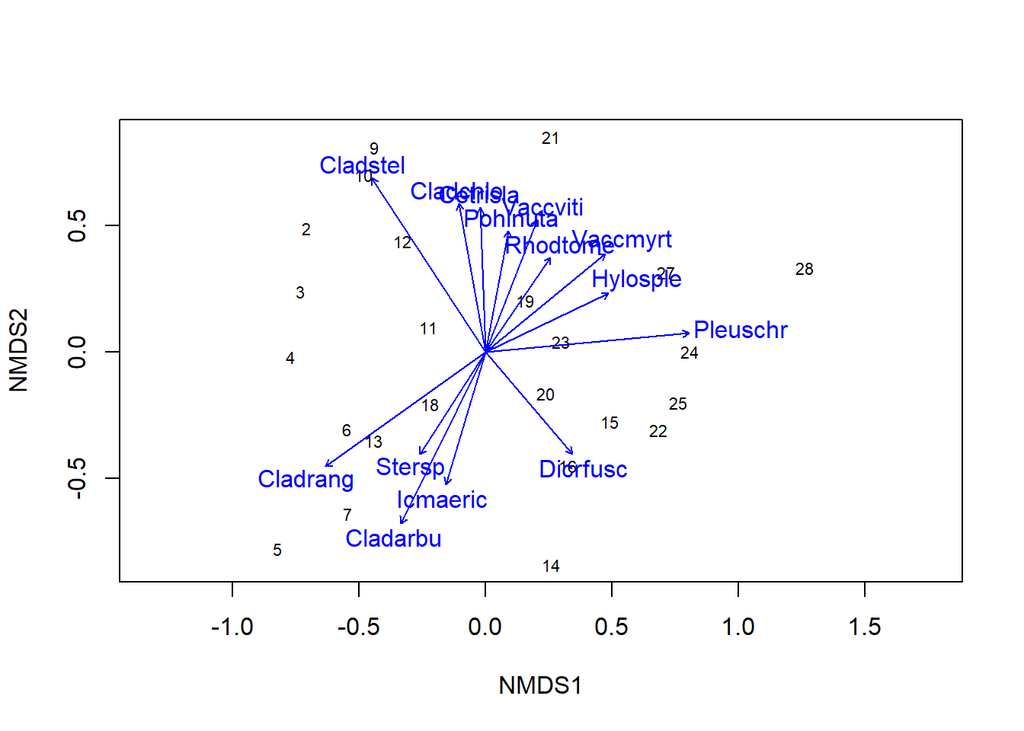

```r
# The two last columns are of interest: the squared correlation coefficient and the associated p-value
# Plot the vectors of the significant correlations and interpret the plot
plot(NMDS3, type = "t", display = "sites")
plot(ef, p.max = 0.05)
```

#### (c) Cluster analysis

The second interesting thing you can do with the vegan package is a cluster analysis. The cluster analysis comes in 3 step : first, get a distance matrix, secondly, fit a cluster diagram, and thirdly, decide the optimal numbers of groups. Follow this ling for a useful tutorial on cluster analysis with vegan : https://www.introranger.org/post/cluster-analysis/

```r
#yet another quick output if you are in a hurry...
data("varechem") #this data is in the vegan package
head(varechem)
```

```
##       N    P     K    Ca    Mg    S    Al   Fe    Mn   Zn  Mo Baresoil Humdepth
## 18 19.8 42.1 139.9 519.4  90.0 32.3  39.0 40.9  58.1  4.5 0.3     43.9      2.2
## 15 13.4 39.1 167.3 356.7  70.7 35.2  88.1 39.0  52.4  5.4 0.3     23.6      2.2
## 24 20.2 67.7 207.1 973.3 209.1 58.1 138.0 35.4  32.1 16.8 0.8     21.2      2.0
## 27 20.6 60.8 233.7 834.0 127.2 40.7  15.4  4.4 132.0 10.7 0.2     18.7      2.9
## 23 23.8 54.5 180.6 777.0 125.8 39.5  24.2  3.0  50.1  6.6 0.3     46.0      3.0
## 19 22.8 40.9 171.4 691.8 151.4 40.8 104.8 17.6  43.6  9.1 0.4     40.5      3.8
##     pH
## 18 2.7
## 15 2.8
## 24 3.0
## 27 2.8
## 23 2.7
## 19 2.7
```

```r
#first step
chem_d <- select(varechem, N:Mo) #selecting interesting data
chem_m <- round(vegdist(chem_d, method="euclidean"), 1) #fit distance matrice
as.matrix(chem_m)[c(1:5), c(1:5)]#get matrix
```

```
##       18    15    24    27    23
## 18   0.0 173.5 486.5 342.0 266.9
## 15 173.5   0.0 636.7 498.8 430.8
## 24 486.5 636.7   0.0 230.6 247.3
## 27 342.0 498.8 230.6   0.0 113.7
## 23 266.9 430.8 247.3 113.7   0.0
```

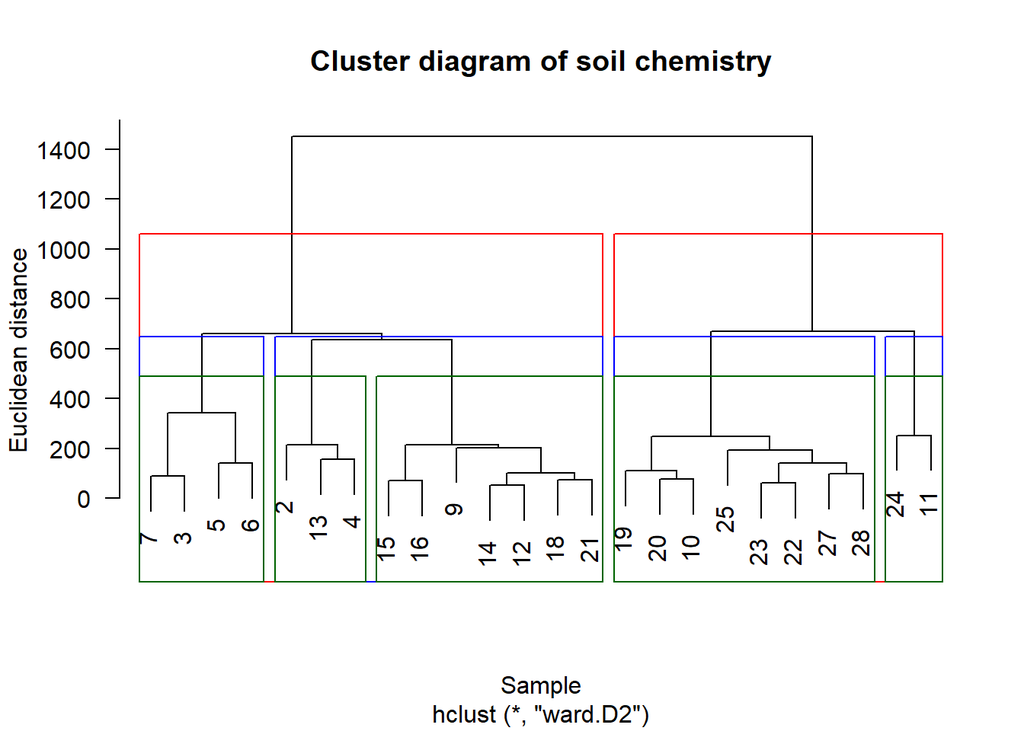

```r
#second step
chem_clust <- hclust(chem_m, method="ward.D2")  #cluster data
plot(chem_clust, las = 1,
     main="Cluster diagram of soil chemistry",
     xlab="Sample",
     ylab="Euclidean distance")
rect.hclust(chem_clust, 2, border="red")
rect.hclust(chem_clust, 4, border="blue")
rect.hclust(chem_clust, 5, border="darkgreen") #plot clustered data with different clustering groups
```

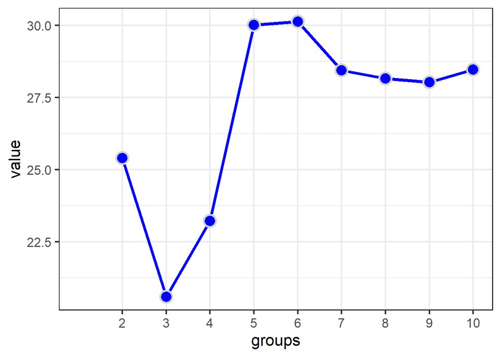

```r
#third step
fit <- cascadeKM(chem_d, 1, 10, iter = 5000)
fit$results %>%
        as.data.frame() %>%
        rownames_to_column("metric") %>%
          pivot_longer(names_to = "groups",
                       values_to = "value",
                       - metric) %>%
        mutate(groups = str_extract(groups, "\\d+"),
               groups = as.numeric(groups)) %>%
  filter(metric != "SSE") %>%
  ggplot(aes(x=groups, y = value)) + theme_bw(16) +
  geom_line(lwd=1.5, col="blue") +
  geom_point(pch=21, col="lightgrey",
             bg="blue", stroke = 1.5, size=5) +
  scale_x_continuous(breaks = c(2:10), labels = c(2:10)) +
  theme(panel.grid.minor.x = element_blank()) #estimate best group number for clustering
```

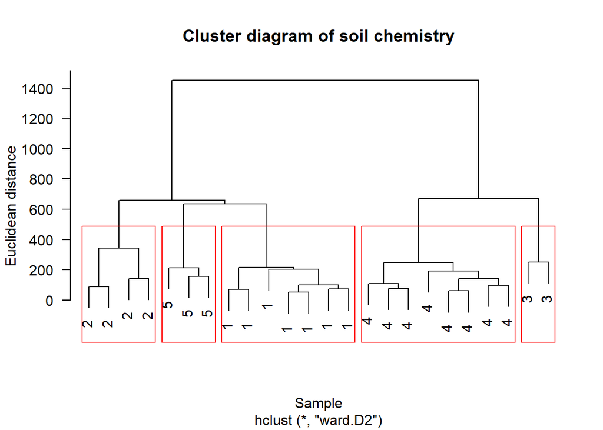

```r
grps <- as_tibble(fit$partition) #put them in a group variable
plot(chem_clust, las = 1,
     label = grps$`5 groups`,
  main="Cluster diagram of soil chemistry",
  xlab="Sample", ylab="Euclidean distance")
  rect.hclust(chem_clust, 5, border="red") #final plot
```